# sustainable_hotels

## Do more expensive hotels offer better quality services? Evidence from twelve European cities.

Author: Ridwan Bello; Date: 23/3/2022

### BACKGROUND

One Saturday in January 2022, I was in my apartment thinking about potential holiday destinations for the year's summer vacations.

Before I go on, let me confess to being a low-budget travel-addict, who has got to meticulously plan his holiday trips well ahead of time in pursuit of the best hotel and flight deals. Or how else does one support wild globetrotting desires on an average income? But, I digress.

While I like to have comfortable accommodation on my holiday trips (let's face it, who doesn't?), I also typically travel on a budget. Thus, I was looking for hotels that would offer quality services at affordable prices.

Besides, I am a pro-environment individual, the kinda guy that supports sustainable businesses and consumption, to the extent possible. Hence, I was also interested in hotels that incorporate sustainability practices into their operations.

Finally, to the extent that my budget could accommodate, I was looking to stay in hotels in or near the city centre. This is to allow easy entry and exit (preferably, by train) into each destination city in my itinerary.

Based on these criteria, I had the following questions about hotel prices in these 12 potential destination cities:

1. In which cities are hotel prices lowest?
2. Do cheaper hotels offer guests less satisfactory services?
3. Are "sustainable" hotels pricier than "non-suatainable" ones?
4. Does proximity of hotel location to city centre influence hotel prices?

These were the questions I needed to answer to be able to make an evidence-based decision. Luckily, as a data scientist, I knew a thing or two about collecting and analyzing data, and I knew a fantastic website that displays just the data I needed. So, I thought "why not? Let's do it!"

### OUTLINE

Over the next 15 (or so) minutes, I will walk you through my data-driven answers to these questions. My presentation comprises four sections, namely:

1. Data Collection
2. Data pre-processing
3. Data analysis
4. Conclusion

Let's go!

### SECTION 1: DATA COLLECTION

The data for this analysis was scrapped from [booking.com](https://booking.com/), the website of a hotel reservation platform. This website displays copious information about hotels and their prices in several cities around the world.

This website also provides a **Travel Sustainable** badge to recognize hotels that incorporate environmentally sustainable practices into their operations. See [here](https://www.sustainability.booking.com/travel-sustainable) for more information about this Travel Sustainable badge.

Using this website, I searched for accommodation options for a one-night stay for two adult guests. I did this for all 12 aforementioned cities and I scrapped the relevant information for all the hotels returned in the search results. The webscrapping code I used is available [here](https://github.com/Ridvanov-Belochevski/Hotel_Analysis/blob/cd8e35f3d44ffae8c7985a7772ba390c600cd3cb/hotels.py).

In total, I collected information on over 6500 hotel properties. The data collected includes variables such as hotel prices, sustainability status, property type, bed type, number of visitors' reviews, visitors' ratings, distance to city center, subway access, prepayement requirement, free cancellation option, and more.

### SECTION 2: DATA PRE-PROCESSING

As you probably know, before we can perform any analysis, we first need to explore and clean the data. Data pre-processing is boring, I know, I know. So, if you'd rather not be bored with these mundane pre-processing details, please scroll down and skip to Section 3.

```python
#Alright! Let's begin by importing the required libraries
import pandas as pd                         #for data manupulation
import os                                   #for managing files and folder directories
from matplotlib import pyplot as plt        #for data vizualization
import seaborn as sns                       #for data vizualization
import numpy as np                          #for data manipulation
import statsmodels.api as sm                #for regression analysis
print("Libraries imported. All systems go!")
```

```
Libraries imported. All systems go!
```

```python
#Next, let's import the scrapped dataset
os.chdir('/Volumes/GoogleDrive/My Drive/Data_Work/Sustainable_Hotels/raw_data_by_cities')
file_name = 'scrapped_hotel_data.xlsx'
hotels_data = pd.read_excel(file_name, sheet_name="All_cities")
print("Data imported.")
```

```
Data imported.
```

```python
#Let's take a look at the first few rows in the dataset.
print(f"The data has {hotels_data.shape[0]} rows and {hotels_data.shape[1]} columns. " +
        "The first 5 rows of the data are shown below:")
display(hotels_data.head())
```

```
The data has 6546 rows and 23 columns. The first 5 rows of the data are shown below:
```

|  | Hotel_name | Normal price | Posted price | City | Distance_value | Distance_unit | Rating | Review_count | Room_description | Bed_description | ... | Free_cancellation_text | Free_cancel_dummy | Prepay_unrequired_dummy | Subway_Access_text | Subway_access_dummy | Breakfast_text | Breakfast_dummy | Sustainable_prop_text | Sust_prop_dummy | Property_type |
| --- | --- | --- | --- | --- | --- | --- | --- | --- | --- | --- | --- | --- | --- | --- | --- | --- | --- | --- | --- | --- | --- |
| 0 | ֍ Splendido Attico - Arsenale - con Terrazza ֍ | NaN | 125 | Venice | 0.4 | miles | 9.1 | 22.0 | Two-Bedroom Apartment | 3 beds (1 twin, 1 sofa bed, 1 queen) | ... | Free cancellation | 1 | 0 | NaN | 0 | NaN | 0 | NaN | 0 | Apartment |
| 1 | "CAL GANXET" | 36.0 | 34 | Barcelona | 3.9 | miles | 8.1 | 205.0 | Economy Double Room | 2 bunk beds | ... | NaN | 0 | 0 | Subway Access | 1 | NaN | 0 | NaN | 0 | Hotel |
| 2 | *King Bed Home+Netflix*Next to Hauptbahnhof | 103.0 | 97 | Vienna | 2.1 | miles | 8.1 | 7.0 | Two-Bedroom Apartment | 3 beds (1 full, 1 sofa bed, 1 queen) | ... | NaN | 0 | 0 | Subway Access | 1 | NaN | 0 | NaN | 0 | Apartment |
| 3 | ⍟3 Bedroom Penthouse⍟ Ideal for large groups | 228.0 | 217 | Vienna | 2.7 | miles | 8.8 | 11.0 | Three-Bedroom Apartment | 5 beds (2 fulls, 2 kings, 1 sofa bed) | ... | NaN | 0 | 0 | Subway Access | 1 | NaN | 0 | NaN | 0 | Apartment |
| 4 | ⍟City Apartment⍟ Next to Hauptbahnhof | NaN | 96 | Vienna | 2.1 | miles | NaN | NaN | One-Bedroom Apartment | 1 queen bed | ... | Free cancellation | 1 | 0 | Subway Access | 1 | NaN | 0 | NaN | 0 | Apartment |

5 rows × 23 columns

We see that there are 6546 hotel observations in the data and 23 columns per observation. Are there duplicates in the data? Let's find out.

```python
no_of_dups = hotels_data.duplicated(subset=['Hotel_name', 'City'], keep='first').sum()
print(f"There are {no_of_dups} duplicated observations in the data.")
```

```
There are 21 duplicated observations in the data.
```

We find 21 duplicates in the data. Note that observations are duplicates if and only if they have the same name and are in the same city.

Now, let's get rid of the duplicates.

```python
hotels_data.drop_duplicates(subset=['Hotel_name', 'City'], keep='first', inplace=True)
print(f"{no_of_dups} duplicates deleted")
```

```
21 duplicates deleted
```

Nicely done.

Now, the main variable of interest to us is **Posted price**. This is the price per night that hotel guests will pay if they reserved a room at the time they found it on booking.com. Note that if a hotel is offering a price discount, the posted price is the reduced price rather than the normal price.

Let's explore the distribution of this variable to check for any outliers.

```
count     6525.000000
mean       175.790958
std        394.325209
min         18.000000
25%         87.000000
50%        126.000000
75%        191.000000
max      21739.000000
Name: Posted price, dtype: float64
```

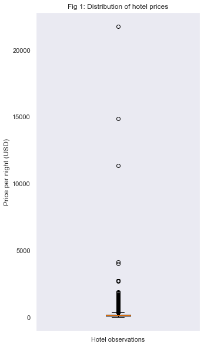

```python
#Print a summary of the variable posted price
print(hotels_data['Posted price'].describe())
print("\n")

#Create a boxplot to check the distibution of Posted price
sns.set_style("dark")
sns.set_context("notebook")
fig, ax = plt.subplots(figsize = (5,10))
ax.boxplot(hotels_data['Posted price'])
ax.set_title("Fig 1: Distribution of hotel prices")
ax.set_xticklabels(["Hotel observations"])
ax.set_ylabel('Price per night (USD)')
plt.show()
```

Oh, look at that! There are several outliers in the data, not the least of which are those observations with markers completely detached from the rest of the plot.

*Do people really stay in a USD20,000 per night hotels? Damn!*

There will come a day when I too will be able to afford excessively priced hotels, but for the purpose of this analysis, they are a real headache for me, as they could bias the results of this analysis.

Thus going forward, I will attempt to make this analysis robust to outliers, for example, by computing median instead of mean when comparing summary statistics, and by dropping outliers when running regression analysis.

Another key variable in this analysis is the distance of hotel location from city centre. A quick look at the frequency distribution of the units of this distance variable show that majority of the distances are recorded in miles but a few are expressed in feet.

```python
print(hotels_data.Distance_unit.value_counts())
```

```
miles    5671
feet       27
Name: Distance_unit, dtype: int64
```

Let's clean up this variable by converting all the distance values to kilometres.

```python
#Convert mile to km by multiplying the distance by 1.609
hotels_data.loc[hotels_data['Distance_unit'] == "miles", "Distance_km"] = (hotels_data['Distance_value'])*1.609
#Convert feet to km by dividing the distance by 3281
hotels_data.loc[hotels_data['Distance_unit'] == "feet", "Distance_km"] = (hotels_data['Distance_value'])/3281
```

Having now cleaned the data, let's confirm that all 12 cities are represented in the scrapped data. The bar chart below helps with that.

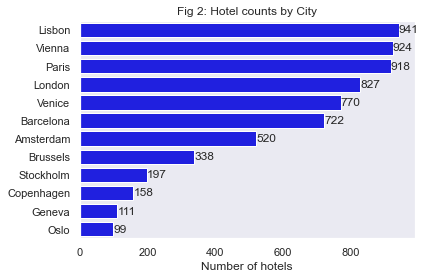

```python
cities_freq = hotels_data.City.value_counts()                       #counts the number of hotels by city
sns.set_context("notebook")                                         #set plot scale
sns.set_style("dark")                                               #specify plot style
g=sns.countplot(
            y="City",                                               #Plot the number of observations by City
            data=hotels_data,
            color="blue",
            order=cities_freq.index,                                #Specify the order of the categories in the City variable
            )
g.set_title("Fig 2: Hotel counts by City")                                 #Add title
g.set(xlabel="Number of hotels", ylabel=None)                                    #Add xlabel
g.bar_label(g.containers[0])                                        #Add data labels
plt.show()
```

Fig 2 shows that there are observations from all 12 cities in the data, ranging from 99 in Oslo to 941 in Lisbon.

There are two things to note here: first, the scrapped data for Paris included hotels in the 1st to 10th arrondisements of Paris only. Paris has [20 arrondisements](https://www.britannica.com/place/Paris#ref364785), but these 10 arrondisements are the ones in or closest to the heart of Paris. Second, the data scrapped for London captured hotels in Central London only, rather than in the Greater London area.

Ordinarily, London and Paris - in their entirety - had well over 2000 hotels in their search results. But considering that webscrapping can burden the website being scrapped, I decided to limit the geographical scope of data collection in these two cities, in order to reduce demand on booking's website.

### STEP 3: DATA ANALYSIS

Okay, here comes the fun part. Let's dive in!

#### QUESTION 1: IN WHICH CITY ARE HOTEL PRICES LOWEST?

The quickest way to answer this question is to compare hotel prices across the 12 cities. Let's try that.

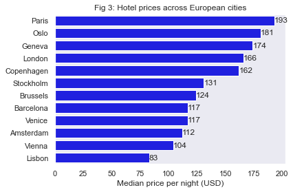

```python
median_prices_by_city = hotels_data.pivot_table(values="Posted price",
                        index="City", aggfunc=np.median)              #computes median hotel prices in each city
median_prices_by_city.sort_values('Posted price', ascending=False,
                        inplace=True)                                 #sorts the result in descending order
cat_order = list(median_prices_by_city.index)

sns.set_style("dark")
sns.set_context("notebook")
g = sns.barplot(y="City",
            x="Posted price",
            data=hotels_data,
            estimator=np.median,
            ci=None,
            color="blue",
            order=cat_order)
g.bar_label(g.containers[0])
g.set(xlabel="Median price per night (USD)", ylabel=None)
g.set_title("Fig 3: Hotel prices across European cities")
plt.show()
```

Based on the median price alone, hotel rooms appear to be cheapest in *Lisbon*, *Vienna*, *Amsterdam*, *Venice* and *Barcelona*, while they are most expensive in *Paris*, *Oslo*, *Geneva*, *Central London* and *Copenhagen*.

However, plots like barplots tend to oversimplify insights in the data because they represent the range of the data with a single summary measure. To get a better sense of the distribution of hotel prices across these cities, let's create a boxplot.

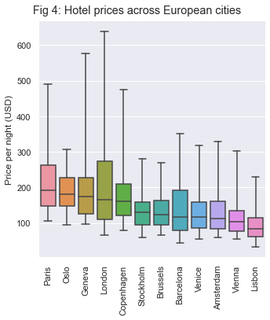

```python
sns.set_style("darkgrid")
g = sns.catplot(y="Posted price",
            x="City",
            kind="box",
            data=hotels_data,
            sym="",
            whis=[5,95],
            order=cat_order)
g.fig.suptitle("Fig 4: Hotel prices across European cities", y=1.02)
g.set(ylabel="Price per night (USD)", xlabel=None)
plt.xticks(rotation=90)
plt.show()
```

Now, this looks interesting!

In Fig 4 above, the boxes represent the [interquartile range](https://en.wikipedia.org/wiki/Interquartile_range) of hotel prices for each city. The low and upper whiskers respectively represent the 5th and 95th [percentiles](https://en.wikipedia.org/wiki/Percentile) of the data for each city.

It turns out that not only are median hotel prices high in cities like *Paris*, *Geneva*, *London* and *Copenhagen*, the range of hotel prices in these cities are also much larger than in other cities in the sample.

One interpretation of this finding is that if I were intending to spend flamboyantly on hotel rooms during my vacations, it is in Paris, Geneva, London, and Copenhagen that I would find highly-priced hotels. Opportunities for such ostentatious display of wealth are limited in the other cities in the data.

*In reality though, I am NOT looking to spend flamboyantly on hotel rooms this summer. In fact, from Fig 3 and Fig 4, I am already starting to identify the cities that I WON'T be visiting in the summer! Lol.*

#### QUESTION 2: DO CHEAPER HOTELS OFFER GUESTS LESS SATISFACTORY ACCOMMODATION SERVICES?

This question is perhaps best answered with a scatterplot showing hotel prices on one axis and guests' ratings of hotels (which is assumed to be a measure of guests' satisfaction) on the other. With such a plot, we would be able to identify the pattern of correlation, if any, between the two. Let's do that.

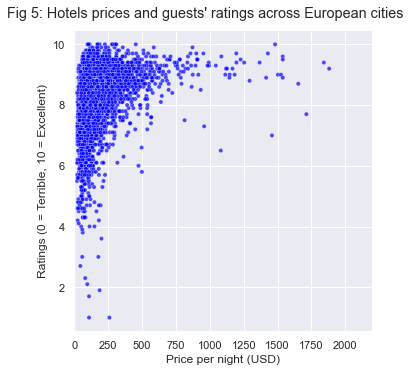

```python
sns.set_style("darkgrid")
sns.set_context("notebook")
g= sns.relplot(kind="scatter",
            x="Posted price",
            y="Rating",
            color="blue",
            alpha=0.7,
            size=3,
            legend=None,
            data=hotels_data)
g.fig.suptitle("Fig 5: Hotels prices and guests' ratings across European cities",
                y=1.03)                                                 #Add title
g.set(xlabel="Price per night (USD)",
    ylabel="Ratings (0 = Terrible, 10 = Excellent)")                    #Add axis labels
plt.xlim(0,2200)                                                        #Exclude observations with outliers price values from plot
plt.show()                                                              #Show plot
```

What is clear from Fig 5 is that guests' ratings - measured on a scale ranging from 0 (Terrible) to 10 (Excellent) - tend to increase with price per night, up until price hits around USD750. Beyond this price, ratings are generally near-maximun levels and seem invariant with price.

Geometrically-minded folks might characterize this pattern as concave, and the 750 threshold as the inflexion point of the concave curve. In plain English though, what this means is that among hotels charging less than USD750 per night (let's call them "regular" hotels), higher hotel prices earn guests better quality services (at least, as reflected by guests' ratings). *Au contraire*, among hotels charging above USD750 per night (let's call them "luxury" hotels), guests tend to receive excellent services regardless of how much they pay per night.

If we create the scatterplot for each city separately, we see a similar concave pattern manifest across many of the 12 cities, but the inflexion point seems to vary across cities (see Fig 6 below). Only in Oslo, Brussels and Stockholm does the data appeear to buck this concave trend.

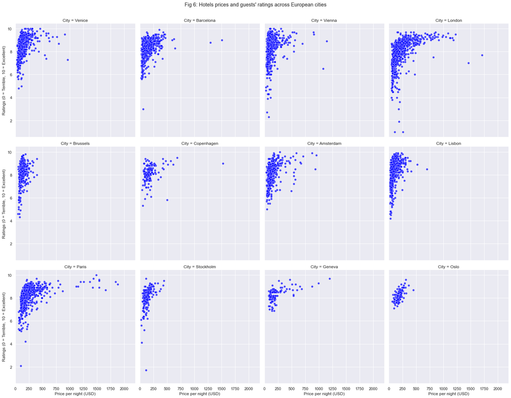

```python
sns.set_style("darkgrid")
sns.set_context("notebook")
g= sns.relplot(kind="scatter",
            x="Posted price",
            y="Rating",
            col="City",
            col_wrap=4,
            color="blue",
            alpha=0.7,
            data=hotels_data)
g.fig.suptitle("Fig 6: Hotels prices and guests' ratings across European cities",
                y=1.03)                                                 #Add title
g.set(xlabel="Price per night (USD)",
    ylabel="Ratings (0 = Terrible, 10 = Excellent)")                    #Add axis labels
plt.xlim(0,2200)                                                        #Exclude observations with outliers price values from plot
plt.show()                                                              #Show plot
```

At this point, my econometrics training compels me to remind the reader that the above finding is correlational, and does not necessarily account for any latent factors driving both hotel prices and guests' ratings. Consider, for example, that "luxury" hotels may charge higher prices for *average* services (partly or wholly) because they are patronized by wealthier guests. However, rich people may also have much higher expectations that may influence their ratings of a hotel's services, regardless of the objective quality of that hotel's services. This possible kind of confounding is unaccounted for in the above analysis. Please, take note.

#### QUESTION 3: ARE "SUSTAINABLE" HOTELS PRICIER THAN "NON-SUSTAINABLE" ONES?

One way to answer this question is with a point plot comparing median prices of sustainable and non-sustainable hotel properties. Check it out below.

```python
hotels_data.replace({"Sust_prop_dummy":{0:"Non-sustainable",1:"Sustainable"}}, inplace=True)
hotels_data.rename(columns={"Sust_prop_dummy":"Hotel sustainability status"}, inplace=True)
```

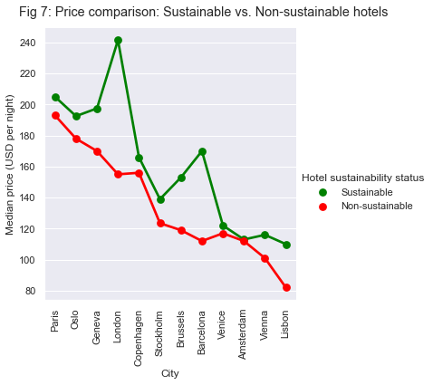

```python
sns.set_context("notebook")
sns.set_style("darkgrid")

g=sns.catplot(y="Posted price",
            x="City",
            hue="Hotel sustainability status",
            data=hotels_data,
            hue_order=["Sustainable","Non-sustainable"],
            order=cat_order,
            kind="point",
            ci=None,
            estimator=np.median,
            palette={'Sustainable':'g','Non-sustainable':'r'}
            )
g.fig.suptitle("Fig 7: Price comparison: Sustainable vs. Non-sustainable hotels", y=1.03)
g.set(ylabel="Median price (USD per night)")
plt.xticks(rotation=90)
plt.show()
```

Fig 7 shows that the median price for a hotel room is perceptibly higher for sustainable hotels than for non-sustainable ones in all cities except Amsterdam. Put another way, in all but one cities, sustainable hotels tend to charge guests more per night than non-sustainable hotels. But, how much more? Let's find out.

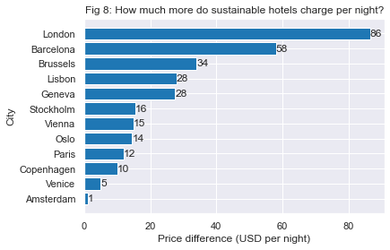

```python
#Sort hotels by city and sustainability status and compute median prices for each group
TSP_by_city = hotels_data.pivot_table('Posted price',
                                        index='City',
                                        columns='Hotel sustainability status',
                                        aggfunc=np.median)              #compute median prices by city and sustainabilty status
TSP_by_city.sort_values('Sustainable', ascending=False, inplace=True)       #Sort data in descending order of price
TSP_by_city['price diff'] = TSP_by_city['Sustainable'] - TSP_by_city['Non-sustainable']
TSP_by_city.sort_values('price diff', ascending=True, inplace=True)
fig, ax = plt.subplots()
fig_2 = ax.barh(TSP_by_city.index, TSP_by_city['price diff'])
ax.set(ylabel="City", xlabel="Price difference (USD per night)")                #Add xlabel and ylabel
ax.bar_label(fig_2, fmt='%.0f')                                                 #Add data labels
ax.set_title("Fig 8: How much more do sustainable hotels charge per night?")    #Adds title
plt.show()
```

As shown in Fig 8, the price differential between sustainable and non-sustainable hotels (let's call it "the sustainaility premium") varies by city, from a low of just USD1 per night in Amsterdam to a high of USD86 per night in London!

*Once again, from an accommodation point of view, London is not doing itself any favours in the quest to become my holiday destination for the Summer! Amsterdam and Venice, on the other hand, are looking like great choices.*

#### QUESTION 4: DOES PROXIMITY TO CITY CENTRE AFFECT HOTEL PRICES?

Apriori, my hypothesis is that hotels located closer to city centres cost more than those located on the contryside. The question is: "by how much do prices rise - if at all, they do - the closer hotel are to the city centre?" A bivariate regression between posted price and distance from city centre should give us some preliminary answers.

Recall that there are some outliers in the data and, given that regression analysis is sensitive to outliers, I think it's a good idea to drop these outliers.

```python
#from a review of the distribution of posted price, I observe that values above USD2714 look very far from the rest of the data
#So I designate observations with prices above USD2714 as outliers
outlier_prices = hotels_data[hotels_data["Posted price"]>2714]

#from a review of the distribution of distance variable, I observe that values above 20km look very far from the rest of the data
#So I designate observations with distance above 20km as outliers
outliers_distance = hotels_data[hotels_data["Distance_km"]>20]

#get the indices of observations with both outlier prices or distances
outliers_all = list(outlier_prices.index) + list(outliers_distance.index)

#drop those indices from the data
hotels_data.drop(index=outliers_all, inplace=True)

print(f"{len(outliers_all)} observations with outlier price or distance values were deleted.")
```

```
12 observations with outlier price or distance values were deleted.
```

Another data quality-related issue that we should address before running the regression is that all observations in London are missing values for the "distance from centre" variable.

Recall that the scrapped data for London only captured hotels in Central London, for all of which booking.com did not provide data on distance from city center. The administrators of the website must have thought that the concept of "distance from city centre" does not apply to Central London. Understandable, albeit undesirable in the context of this analysis.

Anyways, let's drop observations in Central London from the data.

```python
nans = hotels_data[hotels_data["Distance_km"].isna()]
nans_index = list(nans.index)
hotels_data.drop(index=nans_index, inplace=True)
print(f"{len(nans_index)} observations where the distance variable is missing were deleted.")
```

```
826 observations where the distance variable is missing were deleted.
```

Now let's first create a regression plot to visually validate the hypothesis that a relationship does exist between hotel prices and distance from city centre.

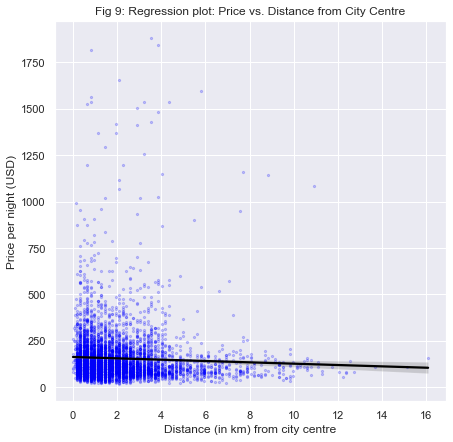

```python
fig, ax = plt.subplots(figsize=(7,7))
sns.regplot(
            data=hotels_data,
            x="Distance_km",
            y="Posted price",
            scatter_kws={'s':5, 'color':'blue', 'alpha':0.2},
            line_kws={'color':'black'},
            ax=ax
            )
ax.set(xlabel="Distance (in km) from city centre",
        ylabel="Price per night (USD)")
ax.set_title("Fig 9: Regression plot: Price vs. Distance from City Centre")
plt.show()
```

Fig 9 shows a slight negative slope in the regression line, which indicates that hotel prices do really tend to reduce as the distance from hotel location to the city centre increases. So let's estimate by how prices rise the closer hotels are located to the city centre.

```python
#Specify the independent variable as "distance"...
distance = hotels_data['Distance_km']

#...and the dependent variable as "price"
price = hotels_data['Posted price']

#Add a constant term to the independent variable
distance_and_constant = sm.add_constant(distance)

#Fit the model, according to the OLS method
results = sm.OLS(price,distance_and_constant).fit()

# Print a summary of the regression results
results.summary()
```

OLS Regression Results

| Dep. Variable: | Posted price | R-squared: | 0.002 |
| --- | --- | --- | --- |
| Model: | OLS | Adj. R-squared: | 0.002 |
| Method: | Least Squares | F-statistic: | 12.80 |
| Date: | Mon, 30 May 2022 | Prob (F-statistic): | 0.000349 |
| Time: | 12:09:03 | Log-Likelihood: | -36112. |
| No. Observations: | 5687 | AIC: | 7.223e+04 |
| Df Residuals: | 5685 | BIC: | 7.224e+04 |
| Df Model: | 1 |  |  |
| Covariance Type: | nonrobust |  |  |

|  | coef | std err | t | P>\|t\| | [0.025 | 0.975] |
| --- | --- | --- | --- | --- | --- | --- |
| const | 163.2961 | 2.738 | 59.631 | 0.000 | 157.928 | 168.664 |
| Distance_km | -3.6106 | 1.009 | -3.578 | 0.000 | -5.589 | -1.632 |

| Omnibus: | 5906.064 | Durbin-Watson: | 1.717 |
| --- | --- | --- | --- |
| Prob(Omnibus): | 0.000 | Jarque-Bera (JB): | 432254.505 |
| Skew: | 5.151 | Prob(JB): | 0.00 |
| Kurtosis: | 44.449 | Cond. No. | 4.37 |

Notes:  
[1] Standard Errors assume that the covariance matrix of the errors is correctly specified.

Oh wo wo wo! What's all these tables and jargons?! What's the key message here?

Well, the key takeaway from these results is that, using the full sample of hotels across 11 cities, there is a *statistically-significant negative relationship between price-per-night and distance from city centre*. This relationship is characterized by an intercept of 163.2961 and a slope coefficient of -3.6106.

Mathematically, the relationship can be expressed as:

```
    price = 163.30 - 3.61*distance_from_city_centre
```

In simple english, what this means is that based on data from 11 European cities, a hotel located 0km from the city center (i.e located in the city centre) charges an average of USD163 per night, but this price drops by USD3.6 for every 1km increase in the distance between the hotel's location and the city centre.

For example, a hotel located, say, 10km from the city centre would charge an average of 10*3.6 = USD36 less than another hotel located right in the city centre.

Again, the big caveat for this result is that *correlation is not causation*, and there may be unexplained factors driving the relationship between distance and price. For this reason, I consider these results descriptive rather than conclusive causal.

## SECTION 4: CONCLUSION

Okay, that's a wrap!

I also found out that hotel prices are related to quality of services... but only for "regular" hotels. For "luxury" hotels, the price does not really matter - guests are almost always going to get excellent services regardless of how much they pay per night.

Finally, I found that prices (per night) increase by an average mark-up of USD3.6 per km as hotel location approaches the city centre. In my experience as a perennial grobetrotter, staying close to city centres often affords tourists easy access to the main attractions in a city, such as the main shopping centres, major transport hubs, best restaurants, and most fun activities. For all that, I would say that USD3.6 per km is a fair price to pay. What do you think?

Many thanks for your time!